# Bikeshare_SpaceTime_Prediction

- Show All Code
- Hide All Code
- View Source

CPLN 5080 - Spring 2026

Author

Yiting Zhong

Published

April 26, 2026

# INTRODUCTION

## The Rebalancing Challenge in Philadelphia

Philadelphia’s Indego bike share system faces the same operational challenge as every bike share system: **rebalancing bikes to meet anticipated demand**.

Imagine you’re an Indego operations manager at 6:00 AM on a Monday morning. You have: - 200 stations across Philadelphia - Limited trucks and staff for moving bikes - 2-3 hours before morning rush hour demand peaks - **The question:** Which stations will run out of bikes by 8:30 AM?

This lab will teach you to build predictive models that forecast bike share demand across **space** (different stations) and **time** (different hours) to help solve this operational problem.

```r
library(tidyverse)
library(lubridate)
library(sf)
library(tigris)
library(tidycensus)

library(knitr)
library(patchwork)
library(kableExtra)
library(here)

options(scipen = 999) # Get rid of scientific notation to make it look tidier
```

```r
plotTheme <- theme_minimal() +
  theme(
    plot.title    = element_text(size = 14, face = "bold"),
    plot.subtitle = element_text(size = 10),
    plot.caption  = element_text(size = 8),
    axis.text.x   = element_text(size = 10, angle = 45, hjust = 1),
    axis.text.y   = element_text(size = 10),
    axis.title    = element_text(size = 11, face = "bold"),
    panel.grid.major = element_line(colour = "#D0D0D0", linewidth = 0.2),
    panel.grid.minor = element_blank(),
    axis.ticks    = element_blank(),
    legend.position = "right"
  )

mapTheme <- theme_void() +
  theme(
    plot.title    = element_text(size = 14, face = "bold"),
    plot.subtitle = element_text(size = 10),
    plot.caption  = element_text(size = 8),
    legend.position  = "right",
    plot.margin      = margin(1, 1, 1, 1, "cm"),
    legend.key.height = unit(1, "cm"),
    legend.key.width  = unit(0.2, "cm")
  )

palette5 <- c("#eff3ff", "#bdd7e7", "#6baed6", "#3182bd", "#08519c")
```

```r
census_api_key(Sys.getenv("CENSUS_API_KEY"))

#Use the following code if you're not able to access the key in your environment
#census_api_key("yourkeyhere", install=TRUE, overwrite=TRUE)
```

# IMPORT AND PREP DATA

## Load Indego Trip Data (Q2 2025)

**Note for HW5:** You’ll download a different quarter from: https://www.rideindego.com/about/data/

```r
# Read Q1 2025 data
indego <- read_csv(here("C:/Users/yzhon/OneDrive - PennO365/Penn-Spring 2026/CPLN 592/cpln-5920-sp26-student-portfolio-template/Labs/Lab_5/indego-trips-2025-q2.csv"))

# Quick look at the data
glimpse(indego)
```

```
Rows: 365,760
Columns: 15
$ trip_id             <dbl> 1164246461, 1164246634, 1164246553, 1164246521, 11…
$ duration            <dbl> 11, 31, 9, 3, 11, 7, 13, 12, 3, 58, 21, 5, 15, 10,…
$ start_time          <chr> "4/1/2025 0:04", "4/1/2025 0:04", "4/1/2025 0:17",…
$ end_time            <chr> "4/1/2025 0:15", "4/1/2025 0:35", "4/1/2025 0:26",…
$ start_station       <dbl> 3022, 3040, 3396, 3054, 3280, 3301, 3158, 3374, 33…
$ start_lat           <dbl> 39.95472, 39.96289, 39.92327, 39.96250, 39.93968, …
$ start_lon           <dbl> -75.18323, -75.16606, -75.18210, -75.17420, -75.21…
$ end_station         <dbl> 3064, 3100, 3349, 3235, 3349, 3051, 3028, 3154, 33…
$ end_lat             <dbl> 39.93840, 39.92777, 39.93651, 39.96000, 39.93651, …
$ end_lon             <dbl> -75.17327, -75.15103, -75.18621, -75.16510, -75.18…
$ bike_id             <chr> "31751", "14481", "02724", "24841", "25744", "3123…
$ plan_duration       <dbl> 30, 30, 30, 365, 30, 365, 1, 30, 30, 30, 30, 30, 1…
$ trip_route_category <chr> "One Way", "One Way", "One Way", "One Way", "One W…
$ passholder_type     <chr> "Indego30", "Indego30", "Indego30", "Indego365", "…
$ bike_type           <chr> "electric", "standard", "standard", "electric", "e…
```

**Pause here** Look at the data. What do you suspect the coordinate system is? What do you notice about the date and time structure?

> The coordinate fields suggest that the data uses geographic coordinates in latitude and longitude, likely in decimal degrees (such as WGS84). The time variables are stored as full timestamps with both date and time, rather than date alone. Because each trip has a start and end timestamp, the data will likely need to be aggregated to hourly intervals for station-hour analysis.

## Examine the Data Structure

```r
# How many trips?
cat("Total trips in Q2 2025:", nrow(indego), "\n")
```

```
Total trips in Q2 2025: 365760
```

```r
# Date range
cat("Date range:",
    min(mdy_hm(indego$start_time)), "to",
    max(mdy_hm(indego$start_time)), "\n")
```

```
Date range: 1743465840 to 1751327820
```

```r
# How many unique stations?
cat("Unique start stations:", length(unique(indego$start_station)), "\n")
```

```
Unique start stations: 273
```

```r
# Trip types
table(indego$trip_route_category)
```

```
   One Way Round Trip
    341060      24700
```

```r
# Passholder types
table(indego$passholder_type)
```

```
  Day Pass   Indego30  Indego365 IndegoFlex       NULL    Walk-up
     15712     189135     132693          1          4      28215
```

```r
# Bike types
table(indego$bike_type)
```

```
electric standard
  234502   131258
```

## Create Time Bins

We need to aggregate trips into hourly intervals for our panel data structure. Read up on the lubridate library for more information on the date/time data extraction.

```r
indego <- indego %>%
  mutate(
    # Parse datetime
    start_datetime = mdy_hm(start_time),
    end_datetime = mdy_hm(end_time),

    # Create hourly bins
    interval60 = floor_date(start_datetime, unit = "hour"),

    # Extract time features
    week = week(interval60),
    month = month(interval60, label = TRUE),
    dotw = wday(interval60, label = TRUE),
    hour = hour(interval60),
    date = as.Date(interval60),

    # Create useful indicators
    weekend = ifelse(dotw %in% c("Sat", "Sun"), 1, 0),
    rush_hour = ifelse(hour %in% c(7, 8, 9, 16, 17, 18), 1, 0)
  )

# Look at temporal features
head(indego %>% select(start_datetime, interval60, week, dotw, hour, weekend))
```

```
# A tibble: 6 × 6
  start_datetime      interval60           week dotw   hour weekend
  <dttm>              <dttm>              <dbl> <ord> <int>   <dbl>
1 2025-04-01 00:04:00 2025-04-01 00:00:00    13 Tue       0       0
2 2025-04-01 00:04:00 2025-04-01 00:00:00    13 Tue       0       0
3 2025-04-01 00:17:00 2025-04-01 00:00:00    13 Tue       0       0
4 2025-04-01 00:20:00 2025-04-01 00:00:00    13 Tue       0       0
5 2025-04-01 00:25:00 2025-04-01 00:00:00    13 Tue       0       0
6 2025-04-01 00:40:00 2025-04-01 00:00:00    13 Tue       0       0
```

**Question** Explain the interval60 feature to someone else at your table.

> `interval60` is an hourly time bin created from the trip start time. It rounds each trip down to the start of the hour, so trips that begin within the same hour are grouped together. This is useful because the analysis predicts bike demand at the station-hour level rather than for individual trips.

## Trips Over Time

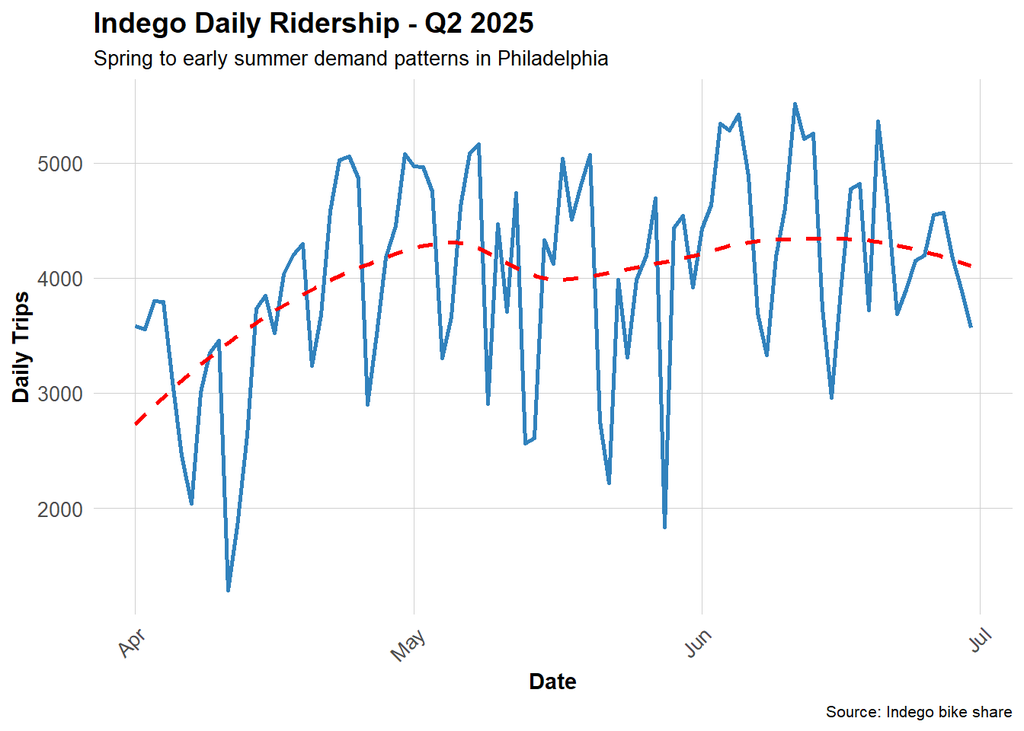

```r
# Daily trip counts
daily_trips <- indego %>%
  group_by(date) %>%
  summarize(trips = n())

ggplot(daily_trips, aes(x = date, y = trips)) +
  geom_line(color = "#3182bd", linewidth = 1) +
  geom_smooth(se = FALSE, color = "red", linetype = "dashed") +
  labs(
    title = "Indego Daily Ridership - Q2 2025",
    subtitle = "Spring to early summer demand patterns in Philadelphia",
    x = "Date",
    y = "Daily Trips",
    caption = "Source: Indego bike share"
  ) +
  plotTheme
```

**Question:** What patterns do you see? How does ridership change over time?

The plot suggests that Indego ridership rises overall during Q2 2025. The red smoothed line increases from April through June, indicating stronger demand as the quarter progresses. In addition, the blue daily series shows regular up-and-down variation, which suggests a repeating weekly cycle in bike use. There are also several unusually low-ridership days, which may reflect weekends, weather conditions, or other one-off disruptions.

## Hourly Patterns

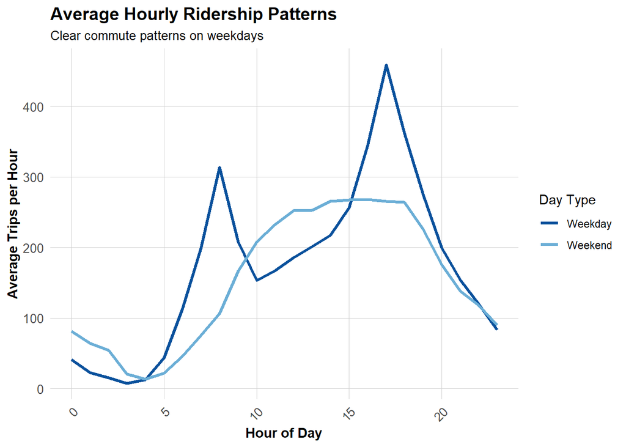

```r
# Average trips by hour and day type
hourly_patterns <- indego %>%
  group_by(hour, weekend) %>%
  summarize(avg_trips = n() / n_distinct(date)) %>%
  mutate(day_type = ifelse(weekend == 1, "Weekend", "Weekday"))

ggplot(hourly_patterns, aes(x = hour, y = avg_trips, color = day_type)) +
  geom_line(linewidth = 1.2) +
  scale_color_manual(values = c("Weekday" = "#08519c", "Weekend" = "#6baed6")) +
  labs(
    title = "Average Hourly Ridership Patterns",
    subtitle = "Clear commute patterns on weekdays",
    x = "Hour of Day",
    y = "Average Trips per Hour",
    color = "Day Type"
  ) +
  plotTheme
```

**Question:** When are the peak hours? How do weekends differ from weekdays?

The busiest hours on weekdays are around 8 AM and especially 4–6 PM, with the strongest peak at 5 PM. In contrast, weekends do not show a sharp morning peak. Instead, weekend ridership builds gradually and remains high from around noon through the late afternoon. This suggests a commuter pattern on weekdays and a more leisure-oriented pattern on weekends.

## Top Stations

```r
# Most popular origin stations
top_stations <- indego %>%
  count(start_station, start_lat, start_lon, name = "trips") %>%
  arrange(desc(trips)) %>%
  head(20)

kable(top_stations,
      caption = "Top 20 Indego Stations by Trip Origins",
      format.args = list(big.mark = ",")) %>%
  kable_styling(bootstrap_options = c("striped", "hover"))
```

Top 20 Indego Stations by Trip Origins

| start_station | start_lat | start_lon | trips |
| --- | --- | --- | --- |
| 3,010 | 39.94711 | -75.16618 | 6,278 |
| 3,032 | 39.94527 | -75.17971 | 4,751 |
| 3,359 | 39.94888 | -75.16978 | 4,181 |
| 3,028 | 39.94061 | -75.14958 | 4,028 |
| 3,163 | 39.94974 | -75.18097 | 4,000 |
| 3,020 | 39.94855 | -75.19007 | 3,946 |
| 3,185 | 39.95169 | -75.15888 | 3,914 |
| 3,066 | 39.94561 | -75.17348 | 3,899 |
| 3,022 | 39.95472 | -75.18323 | 3,856 |
| 3,054 | 39.96250 | -75.17420 | 3,767 |
| 3,161 | 39.95486 | -75.18091 | 3,629 |
| 3,362 | 39.94816 | -75.16226 | 3,552 |
| 3,063 | 39.94633 | -75.16980 | 3,516 |
| 3,213 | 39.93887 | -75.16663 | 3,332 |
| 3,059 | 39.96244 | -75.16121 | 3,320 |
| 3,012 | 39.94218 | -75.17747 | 3,264 |
| 3,007 | 39.94517 | -75.15993 | 3,242 |
| 3,061 | 39.95425 | -75.17761 | 3,193 |
| 3,101 | 39.94295 | -75.15955 | 3,170 |
| 3,296 | 39.95134 | -75.16758 | 3,088 |

# PUT DATA IN CONTEXT

## Load Philadelphia Census Data

We’ll get census tract data to add demographic context to our stations.

```r
# Get Philadelphia census tracts
philly_census <- get_acs(
  geography = "tract",
  variables = c(
    "B01003_001",  # Total population
    "B19013_001",  # Median household income
    "B08301_001",  # Total commuters
    "B08301_010",  # Commute by transit
    "B02001_002",  # White alone
    "B25077_001"   # Median home value
  ),
  state = "PA",
  county = "Philadelphia",
  year = 2022,
  geometry = TRUE,
  output = "wide"
) %>%
  rename(
    Total_Pop = B01003_001E,
    Med_Inc = B19013_001E,
    Total_Commuters = B08301_001E,
    Transit_Commuters = B08301_010E,
    White_Pop = B02001_002E,
    Med_Home_Value = B25077_001E
  ) %>%
  mutate(
    Percent_Taking_Transit = (Transit_Commuters / Total_Commuters) * 100,
    Percent_White = (White_Pop / Total_Pop) * 100
  ) %>%
  st_transform(crs = 4326)  #transforming to WGS84 for lat/lon matching, currently in NAD83
# Check the data
glimpse(philly_census)
```

```
Rows: 408
Columns: 17
$ GEOID                  <chr> "42101001500", "42101001800", "42101002802", "4…
$ NAME                   <chr> "Census Tract 15; Philadelphia County; Pennsylv…
$ Total_Pop              <dbl> 3251, 3300, 5720, 4029, 4415, 1815, 3374, 2729,…
$ B01003_001M            <dbl> 677, 369, 796, 437, 853, 210, 480, 734, 763, 11…
$ Med_Inc                <dbl> 110859, 114063, 78871, 61583, 32347, 48581, 597…
$ B19013_001M            <dbl> 24975, 30714, 20396, 22293, 4840, 13812, 6278, …
$ Total_Commuters        <dbl> 2073, 2255, 3032, 2326, 1980, 969, 2427, 708, 2…
$ B08301_001M            <dbl> 387, 308, 478, 383, 456, 189, 380, 281, 456, 68…
$ Transit_Commuters      <dbl> 429, 123, 685, 506, 534, 192, 658, 218, 438, 51…
$ B08301_010M            <dbl> 188, 66, 219, 144, 285, 71, 278, 184, 176, 235,…
$ White_Pop              <dbl> 2185, 2494, 3691, 3223, 182, 984, 2111, 231, 35…
$ B02001_002M            <dbl> 268, 381, 592, 380, 88, 190, 463, 112, 238, 778…
$ Med_Home_Value         <dbl> 568300, 605000, 350600, 296400, 76600, 289700, …
$ B25077_001M            <dbl> 58894, 34876, 12572, 22333, 10843, 118720, 1506…
$ geometry               <MULTIPOLYGON [°]> MULTIPOLYGON (((-75.16558 3..., MU…
$ Percent_Taking_Transit <dbl> 20.694645, 5.454545, 22.592348, 21.754084, 26.9…
$ Percent_White          <dbl> 67.2100892, 75.5757576, 64.5279720, 79.9950360,…
```

## Map Philadelphia Context

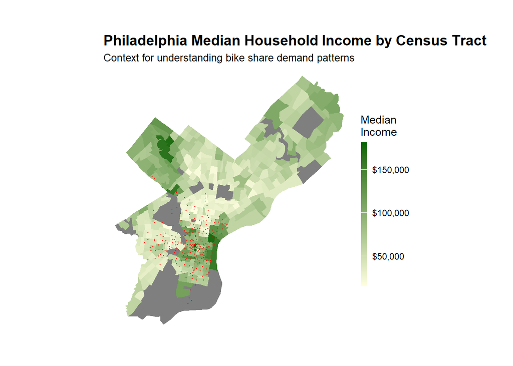

```r
ggplot() +
  geom_sf(data = philly_census, aes(fill = Med_Inc), color = NA) +
  scale_fill_gradient(
    low = "lightyellow",
    high = "darkgreen",
    name = "Median\nIncome",
    labels = scales::dollar
  ) +
  labs(
    title = "Philadelphia Median Household Income by Census Tract",
    subtitle = "Context for understanding bike share demand patterns"
  ) +
  geom_point(
    data = indego,
    aes(x = start_lon, y = start_lat),
    color = "red", size = 0.25, alpha = 0.6
  ) +
  mapTheme
```

**Question** These data are in WGS84. If you wanted to calculate a spatial distance-based variable, like a buffer, should you use the dataset as it?

No. WGS84 stores coordinates in latitude and longitude (degrees), so it is not ideal for calculating distance-based measures such as buffers. For spatial distance calculations, the data should first be projected into a coordinate system with linear units such as meters or feet.